# H06 daily metrics — METRIC-011 L10 amendment

Two-part L10 analysis and estimability stop gate

Published

August 12, 2026

**ImportantAnswer in brief**

The approved METRIC-011 normalization correctly reclassified eight proven roundoff remnants as exact zero L10 mean melEDI values. Those participant-days were retained: exact zeros entered the occurrence component and only the strictly positive magnitude component excluded them.

The prespecified fixed-site occurrence model is nevertheless **not estimable for any of the three primary near-eye context tests** because site-specific zero patterns cause complete or quasi-complete separation. The work/free actual-date AR(1) counterpart also failed at the correlation boundary ($\rho=-0.999964$). Consequently, the overall two-part L10 association and site-heterogeneity tests are `NON_ESTIMABLE_COMPONENT_FAILURE`; their raw and adjusted p-values are missing. The named L10 slot remains in each 15-metric Benjamini–Hochberg family. No L10 joint association is claimed.

Among participant-days with L10 greater than zero, the Gaussian component can be shown descriptively with pointwise 95% intervals, but it cannot replace the joint estimand. Its work/free result reverses direction under the Student-t sensitivity, the activity result has a 1.04-standard-error site-deletion shift, and the sleep Student-t sensitivity fails its numerical gate. None supports a standalone confirmatory or directional claim.

This report stops at **H06-D-G2P-L10-METRIC011** for an author decision. It does not release the remaining daily-metric grid or alter the approved pre-sleep no-nugget sensitivity.

# 1 Scope and controlling METRIC-011 rule

L10 mean melEDI is the arithmetic mean melEDI during the least-active 10-hour period of an admissible participant-day, reported in lx. METRIC-011 changes a derived L10 value to exact zero only when the value is within the shared machine-precision rule **and every contributing source minute is exactly zero**. It is not a fitted-model cutoff and does not round genuinely low positive exposure.

The shared repair changed three near-eye and five chest participant-day cells. All non-L10 scientific values, samples, hourly values, 30-minute values, and gap-timing-unaware L10 values were unchanged. H06_daily consumed the sealed artifacts; it did not rebuild preparation.

Table 1: Controlling METRIC-011 inputs. Every displayed identity was verified before fitting.

| Input | Role | SHA-256 (first 12) | Verified |
| --- | --- | --- | --- |
| metric011_decision | controlling numerical-zero decision | 23b9f70d1d16 | Yes |
| metric011_evidence_manifest | independent implementation evidence | a37efd3449a8 | Yes |
| metric_manifest | current shared metric manifest | 028bce108339 | Yes |
| site_context_manifest | current shared site/context manifest | c0c6d7f97782 | Yes |
| base_manifest | current shared base-model-data manifest | 8344bdc0339a | Yes |
| primary_near_eye | near-eye participant-day L10 source | 013afe75e9b7 | Yes |
| primary_chest | chest participant-day L10 source | 497466ccd1a3 | Yes |
| gap_manifest | gap-timing-unaware artifact manifest | 4ed62fbe58de | Yes |
| gap_participant_day | gap-timing-unaware L10 values | 7561b5dd47cb | Yes |
| metric011_changed_cells | exact eight primary changed cells | a32b850d7af2 | Yes |
| exercise_diary | immutable daily activity context | 5bffe44cdd9c | Yes |
| sleep_diary | immutable work/free and previous-night sleep context | 110819d74503 | Yes |
| site_registry | submitted site order and display names | 3d669d459ecc | Yes |

# 2 Estimand and model contract

Each model frame has one metric-specific participant-day per row. The prespecified two-part analysis separates:

1. **Occurrence:** $P(\mathrm{L10}=0\mid X)$, using a binomial logit model in which an exact zero is the event; and
2. **Positive magnitude:** $E[\log_{10}(\mathrm{L10})\mid \mathrm{L10}>0,X]$, using a Gaussian identity mixed model, with a Student-t identity model as the mandatory response-family sensitivity.

The fixed-site additive formula used in both components was:

```r
response_value ~ site + predictor + (1 | participant_key)
```

The site-heterogeneity comparison used:

```r
response_value ~ site * predictor + (1 | participant_key)
```

An overall two-part likelihood-ratio test was to combine the component likelihood-ratio statistics only if **both** components passed their component-appropriate estimability and diagnostic gates. That condition did not hold. The Gaussian positive-component ratio is $10^{\widehat\beta}$: a conditional geometric-mean ratio among days with L10 greater than zero, not a marginal mean ratio across all days.

The exact registered benchmark was retained without simplification:

```r
response_value ~ predictor + (predictor | site) +
  (1 | site:participant_key)
```

It remains a benchmark only. It was not promoted to replace the prespecified fixed-site primary model.

# 3 Exact samples and zero handling

The occurrence component keeps every model-eligible day. The positive component excludes only exact-zero L10 days. The table gives exact fitted support as days / participants / sites.

Table 2: Exact component samples for every authorized scenario and predictor.

| Predictor | Participant-days / participants / sites Occurrence | Participant-days / participants / sites Positive magnitude |
| --- | --- | --- |
| Primary near eye, all available |  |  |
| Work/free day | 784 / 141 / 9 | 677 / 139 / 9 |
| Activity status | 734 / 137 / 9 | 642 / 135 / 9 |
| Previous-night sleep | 784 / 141 / 9 | 677 / 139 / 9 |
| Primary chest, all available |  |  |
| Work/free day | 870 / 154 / 8 | 752 / 153 / 8 |
| Activity status | 810 / 149 / 8 | 708 / 149 / 8 |
| Previous-night sleep | 870 / 154 / 8 | 752 / 153 / 8 |
| Primary near eye, paired/common |  |  |
| Work/free day | 614 / 112 / 8 | 512 / 110 / 8 |
| Activity status | 571 / 109 / 8 | 482 / 107 / 8 |
| Previous-night sleep | 614 / 112 / 8 | 512 / 110 / 8 |
| Primary chest, paired/common |  |  |
| Work/free day | 614 / 112 / 8 | 512 / 110 / 8 |
| Activity status | 571 / 109 / 8 | 483 / 108 / 8 |
| Previous-night sleep | 614 / 112 / 8 | 512 / 110 / 8 |
| Gap-timing-unaware near eye |  |  |
| Work/free day | 777 / 141 / 9 | 665 / 137 / 9 |
| Activity status | 729 / 137 / 9 | 632 / 133 / 9 |
| Previous-night sleep | 777 / 141 / 9 | 665 / 137 / 9 |
| Gap-timing-unaware chest |  |  |
| Work/free day | 863 / 154 / 8 | 739 / 152 / 8 |
| Activity status | 803 / 149 / 8 | 697 / 148 / 8 |
| Previous-night sleep | 863 / 154 / 8 | 739 / 152 / 8 |

Across all source scenarios and placements, 493 exact-zero L10 rows were audited. The eight METRIC-011 reclassifications are included among them. No participant-day was discarded merely because L10 equals zero.

# 4 Why the primary joint estimand is not available

The primary near-eye occurrence frames contain substantial overall zero mass, but the event is absent in structurally important site cells. In particular, UCR has no zero L10 day under either work/free category, either activity category, or anywhere over the observed sleep-duration support. With site fixed effects in a logistic mixed model, these empty event cells drive fixed coefficients toward the boundary: maximum absolute coefficients were 16.41–16.93 and maximum standard errors were 5,003–6,833.

Table 3: Primary near-eye UCR occurrence support, showing the zero-free site cells central to separation.

| Predictor | Level | Days | Exact-zero days | Positive days |
| --- | --- | --- | --- | --- |
| Work/free day | Free day | 8 | 0 | 8 |
| Work/free day | Work day | 23 | 0 | 23 |
| Activity status | Active | 9 | 0 | 9 |
| Activity status | Sedentary | 19 | 0 | 19 |
| Previous-night sleep | continuous support | 31 | 0 | 31 |

Table 4: Primary near-eye component and joint-test dispositions. Missing p-values are intentional estimability decisions.

| Component | Status | Ordinary raw p-value |
| --- | --- | --- |
| Work/free day |  |  |
| Overall two-part | Non-estimable: component failure | — |
| Positive magnitude | Descriptive only: major family sensitivity | withheld |
| Occurrence | Non-estimable: separation and AR failure | — |
| Activity status |  |  |
| Overall two-part | Non-estimable: component failure | — |
| Positive magnitude | Descriptive only: family sensitivity | withheld |
| Occurrence | Non-estimable: separation | — |
| Previous-night sleep |  |  |
| Overall two-part | Non-estimable: component failure | — |
| Positive magnitude | Descriptive only: Student-t fit failed | withheld |
| Occurrence | Non-estimable: separation | — |

The small ordinary likelihood-ratio p-values generated before the separation gate were retained only in diagnostic provenance. They are **not accepted results**, are not displayed as association evidence, and do not enter BH.

## 4.1 Actual-date AR(1) checks

Actual-date AR(1) counterparts were fitted only when the prespecified residual lag screen triggered and calendar adjacency was adequate. For work/free occurrence, the fitted $\rho=-0.999964$ is a boundary failure; its likelihood and coefficients are unusable for inference and do not repair separation. For positive L10 with previous-night sleep, $\rho=0.836$ and the association coefficient shifted by only 0.039 Gaussian standard errors; that temporal sensitivity passed, but it cannot repair the missing occurrence component.

Table 5: Triggered primary near-eye actual-date AR(1) counterparts.

| Predictor | Component | Rho | Shift (primary SE) | Disposition |
| --- | --- | --- | --- | --- |
| Work/free day | Occurrence | -1.000 | 0.021 | Not acceptable: rho boundary |
| Previous-night sleep | Positive magnitude | 0.836 | 0.039 | Acceptable temporal sensitivity |

# 5 Positive-magnitude component: descriptive only

The following ratios condition on L10 being strictly greater than zero. They exclude zero days by definition and therefore do not answer the overall L10 question. All intervals are model-based **pointwise** 95% intervals; no simultaneous interval was used.

Table 6: Primary near-eye positive-component estimates. Ratios are conditional on L10 greater than zero.

| Family | Ratio (95% pointwise interval) | Interpretation |
| --- | --- | --- |
| Work/free day |  |  |
| Gaussian component | 0.925 (0.759 to 1.128) | Major family sensitivity; direction reverses |
| Student-t sensitivity | 1.061 (0.922 to 1.220) | Major family sensitivity; direction reverses |
| Activity status |  |  |
| Gaussian component | 0.864 (0.674 to 1.107) | Family and site-influence limitations |
| Student-t sensitivity | 0.933 (0.777 to 1.122) | Family and site-influence limitations |
| Previous-night sleep |  |  |
| Gaussian component | 0.775 (0.722 to 0.832) | Student-t numerical failure; sensitivity unresolved |
| Student-t sensitivity | 0.831 (interval withheld) | Student-t numerical failure; sensitivity unresolved |

For work/free day, the Gaussian ratio was 0.925 (0.759 to 1.128), whereas the Student-t ratio was 1.061 (0.922 to 1.220): a 1.35-primary-standard-error shift and a direction reversal. For activity, the response-family shift was 0.61 standard errors, but deleting MPI shifted the Gaussian estimate by 1.04 standard errors. For sleep, the Gaussian ratio per one hour longer previous night was 0.775 (0.722 to 0.832); the Student-t fit reported false convergence and a non-positive-definite Hessian, so its nominal interval is withheld and the family sensitivity remains unresolved.

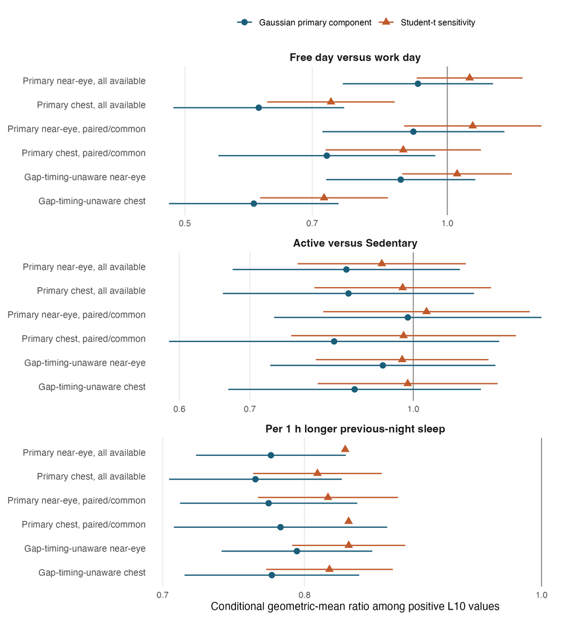

Figure 1: Positive-component response-family and dataset sensitivity. Points are conditional geometric-mean ratios among participant-days with L10 greater than zero. Lines are model-based pointwise 95% intervals; invalid Student-t intervals are withheld. The vertical reference is one. These estimates do not represent the overall L10 association.

## 5.1 Influence diagnostics

The prespecified deletion audit fitted 440 positive-Gaussian deletion models serially with no failures. It did **not** fit occurrence or joint deletion models because those estimands were already non-estimable.

Table 7: Primary near-eye influence diagnostics for the positive Gaussian component only.

| Predictor | Participant deletions | Maximum participant shift (SE) | Maximum site shift (SE) | Most influential site | Disposition |
| --- | --- | --- | --- | --- | --- |
| Work/free day | 139 | 0.43 | 0.69 | FUSPCEU | Acceptable for descriptive positive component |
| Activity status | 135 | 0.33 | 1.04 | MPI | Major limitation; no directional claim |
| Previous-night sleep | 139 | 0.34 | 0.72 | IZTECH | Acceptable for descriptive positive component |

# 6 Regularized occurrence sensitivity

The authorized diagnostic sensitivity used the same fixed-site occurrence frame, formula, and contrasts with normal priors on the log-odds fixed effects. The intercept was explicitly assigned a prior and the same prior was assigned to all remaining conditional fixed effects. The prospective primary scale was $N(0,3^2)$, with $N(0,1.5^2)$ and $N(0,6^2)$ checks.

All nine primary near-eye MAP fits converged. Predictor directions and equal-site predicted zero probabilities changed little over the three scales, but this does not turn a separated ordinary likelihood into an estimable confirmatory test. The MAP coefficients, odds ratios, and predicted probabilities are diagnostic only; there is no ordinary confidence interval, p-value, or BH decision.

Table 8: Regularized primary near-eye occurrence diagnostic across prior scales; no significance decision follows.

| Prior SD | MAP log-odds coefficient | MAP odds ratio | Equal-site zero probability range |
| --- | --- | --- | --- |
| Work/free day |  |  |  |
| 1.5 | 1.066 | 2.903 | 0.063 to 0.142 |
| 3.0 | 1.159 | 3.187 | 0.059 to 0.141 |
| 6.0 | 1.187 | 3.277 | 0.058 to 0.140 |
| Activity status |  |  |  |
| 1.5 | -0.329 | 0.720 | 0.082 to 0.105 |
| 3.0 | -0.298 | 0.742 | 0.082 to 0.102 |
| 6.0 | -0.292 | 0.747 | 0.081 to 0.101 |
| Previous-night sleep |  |  |  |
| 1.5 | 0.394 | 1.483 | 0.097 to 0.129 |
| 3.0 | 0.399 | 1.490 | 0.094 to 0.126 |
| 6.0 | 0.401 | 1.493 | 0.094 to 0.125 |

# 7 Complementary scenarios and gap-timing-unaware comparison

The same two-part contract was completed for chest all-available, placement-paired/common near-eye and chest, and gap-timing-unaware near-eye and chest frames. Any failed occurrence component forced the corresponding joint test to missing. No complementary component estimate replaced a failed primary slot.

All 12 prespecified primary and gap near-eye joint association/heterogeneity tests are non-estimable. The gap L10 scientific values were exactly invariant to METRIC-011; their fits were run only because no accepted production L10 component existed and the previously held branch had to be completed. They are not described as a METRIC-011 scientific repair.

For the positive Gaussian component alone, the gap-minus-primary shifts were 0.45 standard errors for work/free day, 0.63 for activity status, and 0.68 for previous-night sleep. These are descriptive conditional comparisons only.

Table 9: Positive-only primary versus gap-timing-unaware near-eye comparison. Joint two-part sensitivity remains non-estimable.

| Predictor | Primary ratio (95% interval) | Gap-timing-unaware ratio (95% interval) | Absolute shift (primary SE) |
| --- | --- | --- | --- |
| Work/free day | 0.925 (0.759 to 1.128) | 0.884 (0.726 to 1.077) | 0.45 |
| Activity status | 0.864 (0.674 to 1.107) | 0.936 (0.732 to 1.196) | 0.63 |
| Previous-night sleep | 0.775 (0.722 to 0.832) | 0.794 (0.740 to 0.853) | 0.68 |

# 8 Multiplicity disposition

L10 is metric slot 3 in each 15-slot primary association, site-heterogeneity, and gap-timing-unaware family. Its joint raw p-value is missing because a component failed; the slot is retained and the family size remains 15. No isolated component p-value or regularized diagnostic result was substituted.

Within this bounded amendment, only the already frozen MDER slot is otherwise available. Thus every affected family is currently incomplete at 1 of 15, and no BH-adjusted p-value or adjusted decision is produced.

Table 10: L10 multiplicity slots. The family denominator is retained despite non-estimability.

| Predictor | Test | L10 slot status | Raw p-value | BH-adjusted p-value | Available / required |
| --- | --- | --- | --- | --- | --- |
| Gap-timing-unaware |  |  |  |  |  |
| Work/free day | Association | Non-estimable: component failure | — | — | 1 / 15 |
| Work/free day | Site heterogeneity | Non-estimable: component failure | — | — | 1 / 15 |
| Activity status | Association | Non-estimable: component failure | — | — | 1 / 15 |
| Activity status | Site heterogeneity | Non-estimable: component failure | — | — | 1 / 15 |
| Previous-night sleep | Association | Non-estimable: component failure | — | — | 1 / 15 |
| Previous-night sleep | Site heterogeneity | Non-estimable: component failure | — | — | 1 / 15 |
| Primary |  |  |  |  |  |
| Work/free day | Association | Non-estimable: component failure | — | — | 1 / 15 |
| Work/free day | Site heterogeneity | Non-estimable: component failure | — | — | 1 / 15 |
| Activity status | Association | Non-estimable: component failure | — | — | 1 / 15 |
| Activity status | Site heterogeneity | Non-estimable: component failure | — | — | 1 / 15 |
| Previous-night sleep | Association | Non-estimable: component failure | — | — | 1 / 15 |
| Previous-night sleep | Site heterogeneity | Non-estimable: component failure | — | — | 1 / 15 |

# 9 Diagnostics, preservation, and compute record

The work was bounded to the L10 branch. The production batch completed 18 scenario-by-predictor analyses in one serial R process. The production-code pilot projected 1.59 minutes; the complete production process took 156.67 seconds, principally because sealing and the additional MAP diagnostics took longer than the core fits. No parallel cluster was used. The 50-refit influence pilot projected 0.40 minutes; the full 440-refit positive-only deletion batch took 38.76 seconds.

The no-refit coordinator finalizer changed disposition strings only. All 194 serialized fitted-model subobjects were identical before and after that change. All 294 pre-existing H06_daily scientific/report files in the protected baseline—including the approved pre-sleep no-nugget frame, reference, model, report, and manifests—remained byte-for-byte unchanged after production. No non-L10 model was fitted or revised.

The figure is paired with PNG, PDF, and SVG exports, source-data CSV, alt text, and a passing final-size readability record. Invalid Student-t intervals are withheld rather than plotted. Every displayed interval is pointwise.

# 10 Relationship to V0 and the other H06 estimands

V0 did not fit this two-part participant-day L10 model. The approved hourly H06 analysis estimates context associations in repeated hourly melEDI, and the exploratory temporal GAMM estimates transformed 30-minute profiles over local clock time. This amendment estimates a different daily-metric estimand with one participant-day per row. Their coefficients, weighting, uncertainty, and claims are not numerically interchangeable.

All language here is observational. Recorded work/free day, activity status, and previous-night sleep duration are associated contexts, not randomized exposures; no causal effect or health outcome is inferred.

# 11 H06-D-G2P-L10-METRIC011 stop gate

The bounded L10 branch is complete and sealed. The recommended disposition is:

1. accept the primary occurrence and joint two-part L10 association and site-heterogeneity tests as **non-estimable**, with raw and adjusted p-values missing while retaining the named slot in each 15-metric family;
2. retain Gaussian and Student-t positive-component estimates only as explicitly conditional, descriptive diagnostics with the family, influence, and numerical limitations stated above;
3. retain the normal-prior fixed-site MAP occurrence models only as diagnostic sensitivities, with no ordinary interval, p-value, BH entry, or significance decision; and
4. either leave the L10 joint slot missing or explicitly authorize a new scientific amendment before changing the primary occurrence hierarchy.

Promoting the registered random-site benchmark, deleting UCR, pooling sites, changing the fixed-site hierarchy, or adopting the regularized fit as primary would change the estimand or inferential contract and is **not authorized** by this gate.

No further L10 or remaining-grid work proceeds without an explicit author decision at **H06-D-G2P-L10-METRIC011**.